# HOMEWORK_007

Michael James

April 28, 2019

## PROBLEM 1

> Using the data from the simple regression homework, test the hypothesis that the slopes and intercepts are the same.

### RESULTS

```r
h6p1 <- read.csv("h6p1(1).csv", sep=",")
head(h6p1)
```

```
##   DIET   IV  SUTW
## 1 High  7.5 0.051
## 2 High  9.5 0.051
## 3 High 14.5 0.051
## 4 High 14.0 0.051
## 5 High 20.0 0.051
## 6 High 13.0 0.061
```

```r
summary(h6p1)
```

```
##         DIET          IV             SUTW
##  High     :24   Min.   : 3.50   Min.   :0.01000
##  Low      :24   1st Qu.:13.00   1st Qu.:0.05100
##  reference:24   Median :18.00   Median :0.07100
##                 Mean   :20.19   Mean   :0.07237
##                 3rd Qu.:25.25   3rd Qu.:0.08450
##                 Max.   :45.00   Max.   :0.16300
```

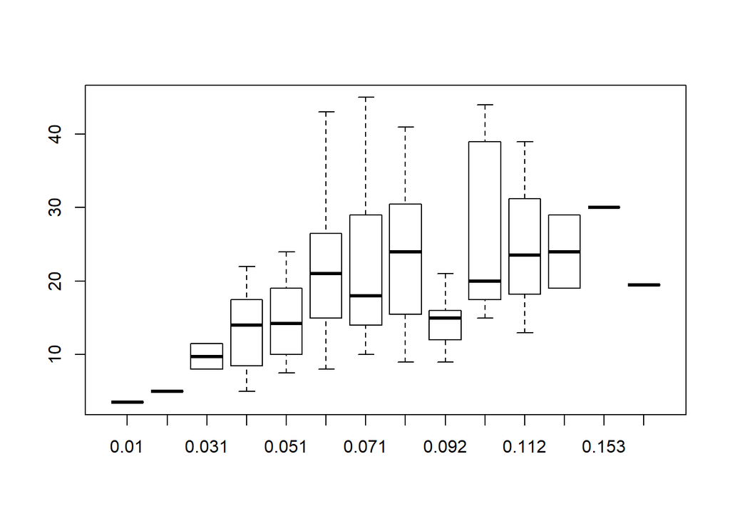

```r
attach(h6p1)
boxplot(IV~SUTW)
```

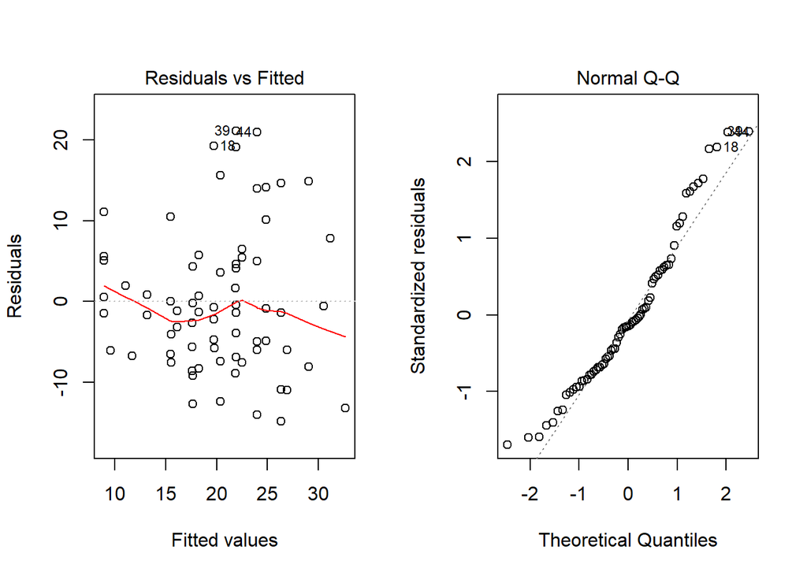

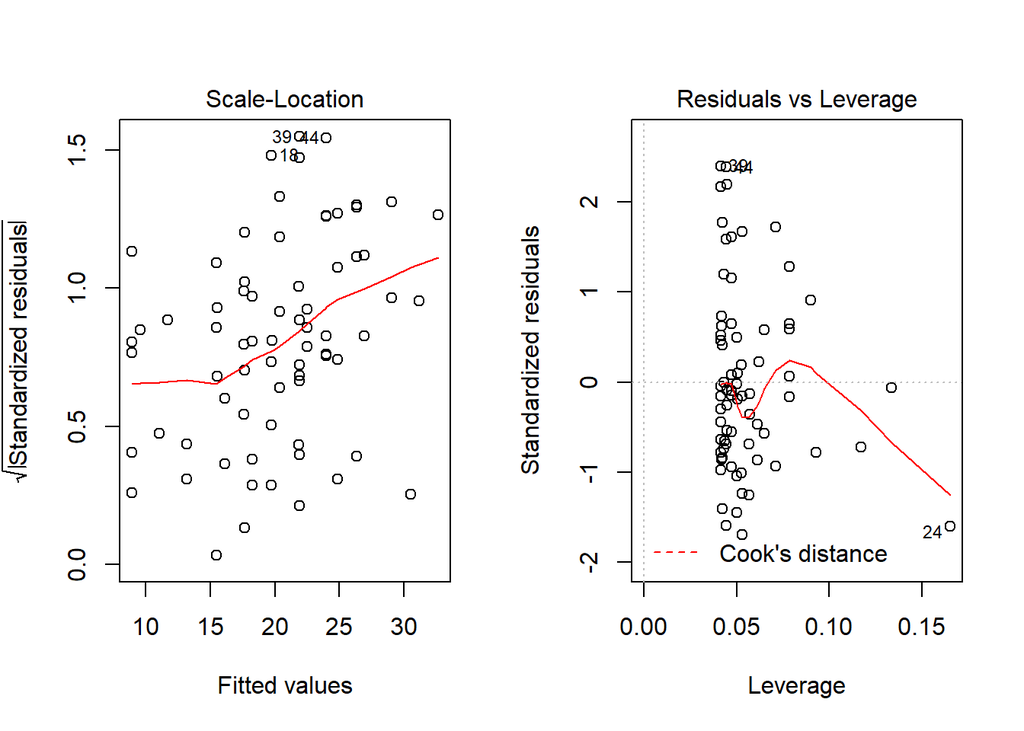

```r
par(mfrow=c(1,2))
plot(aov(IV~SUTW+DIET, which=1))
```

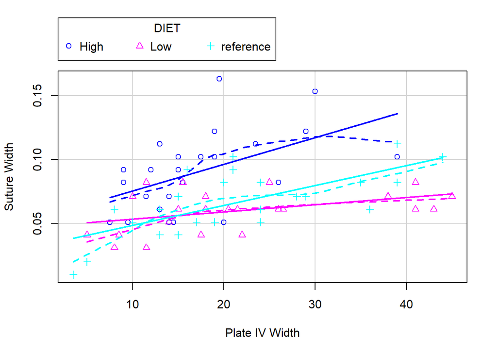

```r
scatterplot(SUTW~IV|DIET, xlab = "Plate IV Width", ylab = "Suture Width")
```

```r
anova(aov(IV~SUTW*DIET))
```

```
## Analysis of Variance Table
##
## Response: IV
##           Df Sum Sq Mean Sq F value    Pr(>F)
## SUTW       1  924.5  924.45 11.8585 0.0010016 **
## DIET       2 1290.0  645.02  8.2740 0.0006218 ***
## SUTW:DIET  2  356.1  178.04  2.2838 0.1098932
## Residuals 66 5145.2   77.96
## ---
## Signif. codes:  0 '***' 0.001 '**' 0.01 '*' 0.05 '.' 0.1 ' ' 1
```

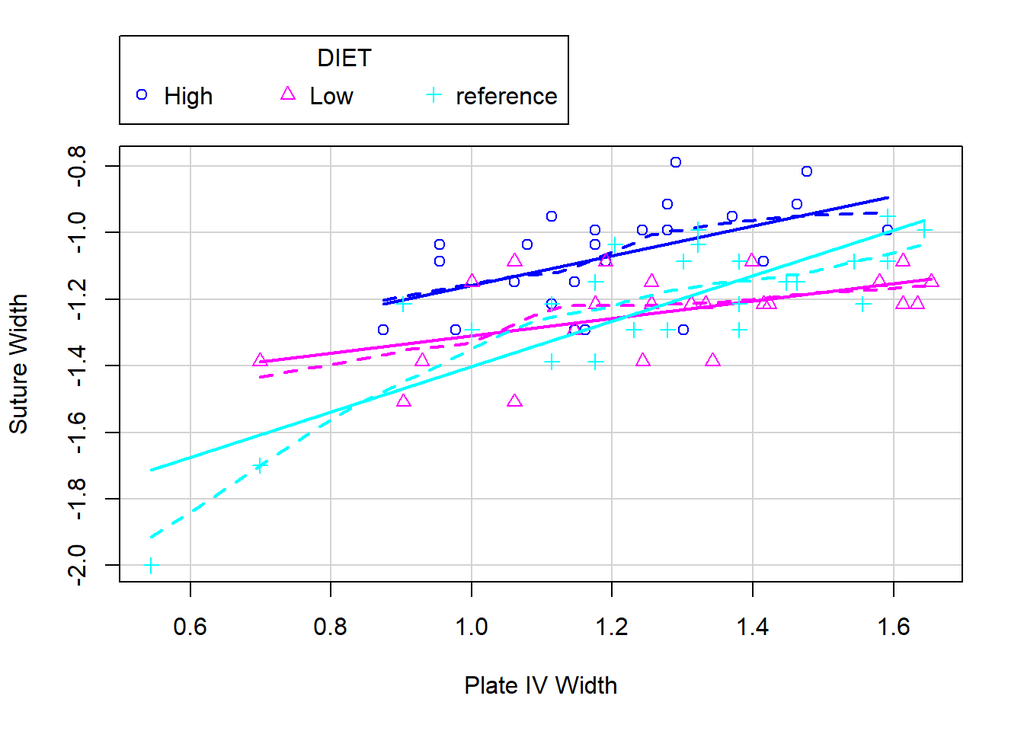

```r
scatterplot(log10(SUTW)~log10(IV)|DIET, xlab = "Plate IV Width", ylab = "Suture Width")
```

```r
data.aov <- aov(log10(IV)~log10(SUTW)+DIET)
anova(data.aov)
```

```
## Analysis of Variance Table
##
## Response: log10(IV)
##             Df  Sum Sq Mean Sq F value    Pr(>F)
## log10(SUTW)  1 1.17065 1.17065 35.4791 1.013e-07 ***
## DIET         2 0.59315 0.29658  8.9884 0.0003438 ***
## Residuals   68 2.24369 0.03300
## ---
## Signif. codes:  0 '***' 0.001 '**' 0.01 '*' 0.05 '.' 0.1 ' ' 1
```

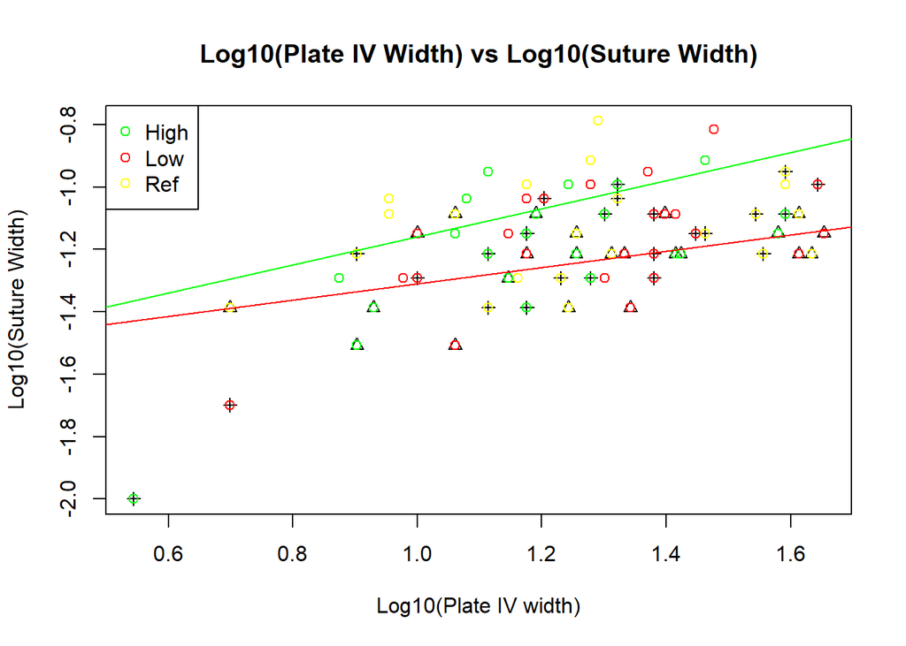

```r
plot(log10(IV), log10(SUTW), pch=as.numeric(DIET), main = "Log10(Plate IV Width) vs Log10(Suture Width)", xlab = "Log10(Plate IV width)", ylab = "Log10(Suture Width)")
points(log10(IV), log10(SUTW), col = c("Green", "Red", "Yellow"))
legend("topleft", legend = c("High", "Low", "Ref"), pch = as.numeric(DIET), col = c("Green", "Red", "Yellow"))
high.diet <- h6p1[h6p1$DIET=="High", ]
low.diet <-h6p1[h6p1$DIET=="Low", ]
lm.high <- lm(log10(SUTW)~log10(IV), data=high.diet)
lm.low <- lm(log10(SUTW)~log10(IV), data=low.diet)
abline(lm.high, col = "Green")
abline(lm.low, col = "Red")
```

```r
summary(lm(log10(SUTW)~log10(IV)+DIET))
```

```
##
## Call:
## lm(formula = log10(SUTW) ~ log10(IV) + DIET)
##
## Residuals:
##      Min       1Q   Median       3Q      Max
## -0.43020 -0.09379  0.00180  0.09277  0.25408
##
## Coefficients:
##               Estimate Std. Error t value Pr(>|t|)
## (Intercept)   -1.64987    0.08568 -19.257  < 2e-16 ***
## log10(IV)      0.48408    0.06758   7.163 7.20e-10 ***
## DIETLow       -0.20386    0.03899  -5.229 1.78e-06 ***
## DIETreference -0.18330    0.03894  -4.707 1.28e-05 ***
## ---
## Signif. codes:  0 '***' 0.001 '**' 0.01 '*' 0.05 '.' 0.1 ' ' 1
##
## Residual standard error: 0.1341 on 68 degrees of freedom
## Multiple R-squared:  0.5236, Adjusted R-squared:  0.5026
## F-statistic: 24.91 on 3 and 68 DF,  p-value: 5.487e-11
```

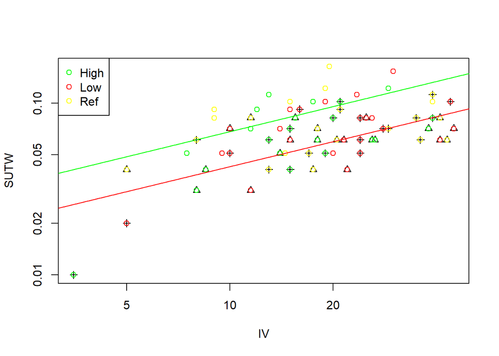

```r
plot(IV, SUTW, pch=as.numeric(DIET), log="xy")
points(IV, SUTW, col = c("Green", "Red", "Yellow"))
legend("topleft", legend = c("High", "Low", "Ref"), pch = as.numeric(DIET), col = c("Green", "Red", "Yellow"))
abline(a=-1.64987, b=0.48408, col = "Green")
abline(a=-1.64987-0.20386, b=0.48408, col = "Red")
```

```r
detach(h6p1)
```

### CONCLUSION

Initial analysis of the data showed the variances were not equal based on diet (F = 8.274, p = 0.0006); however, there was not a linear fit. After linearizing the data by taking the $log_{10}$ we get improved statistics (F = 8.9884, p = 0.0003) thus allowing us to reject the null hypothesis that the variances are equal.

There is a significant effect of plate IV width on suture width after controlling for diet (F(3,68) = 24.91, p <<< 0.05).

## PROBLEM II

> Data from a study on bird fitness and development was collected from urban population in Manaus, Brazil. Birds were categorized by sex and age (days), weight (mg) and wingspan (mm) were recorded.

> Do males and females exhibit similar wingspans relative to weight?

### JUSTIFICATION

Here we have a two-way model with one random effect. We will be looking to see if the variances differ between male and female birds and if the covariance has any effect on the wingspan of said birds.

### RESULTS

```r
h7p2 <- read.csv("h7p2.csv", sep=",")
head(h7p2)
```

```
##   Gender Age Height Wingspan
## 1      f 143   56.3     85.0
## 2      f 191   62.5    112.5
## 3      f 160   62.0     94.5
## 4      f 157   64.5    123.5
## 5      f 191   65.3    107.0
## 6      f 141   61.8     85.0
```

```r
summary(h7p2)
```

```
##  Gender       Age            Height         Wingspan
##  f:111   Min.   :139.0   Min.   :50.50   Min.   : 50.5
##  m:126   1st Qu.:148.0   1st Qu.:58.80   1st Qu.: 85.0
##          Median :163.0   Median :61.50   Median :101.0
##          Mean   :164.4   Mean   :61.36   Mean   :101.3
##          3rd Qu.:178.0   3rd Qu.:64.30   3rd Qu.:112.0
##          Max.   :250.0   Max.   :72.00   Max.   :171.5
```

“Height” is actually supposed to be “Weight.” Let’s fix that.

```r
attach(h7p2)
colnames(h7p2)[colnames(h7p2)=="Height"] <- "Weight"
head(h7p2)
```

```
##   Gender Age Weight Wingspan
## 1      f 143   56.3     85.0
## 2      f 191   62.5    112.5
## 3      f 160   62.0     94.5
## 4      f 157   64.5    123.5
## 5      f 191   65.3    107.0
## 6      f 141   61.8     85.0
```

```r
summary(h7p2)
```

```
##  Gender       Age            Weight         Wingspan
##  f:111   Min.   :139.0   Min.   :50.50   Min.   : 50.5
##  m:126   1st Qu.:148.0   1st Qu.:58.80   1st Qu.: 85.0
##          Median :163.0   Median :61.50   Median :101.0
##          Mean   :164.4   Mean   :61.36   Mean   :101.3
##          3rd Qu.:178.0   3rd Qu.:64.30   3rd Qu.:112.0
##          Max.   :250.0   Max.   :72.00   Max.   :171.5
```

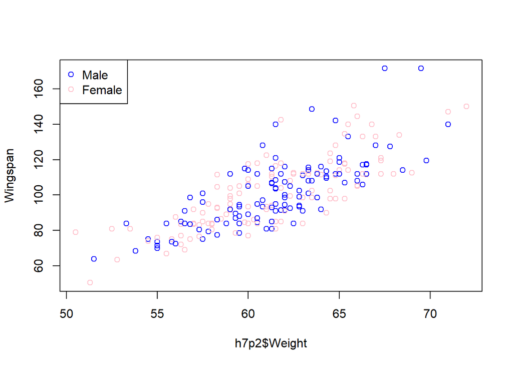

```r
plot(h7p2$Weight, Wingspan) #, pch=as.numeric(Gender))
points(h7p2$Weight, Wingspan, col = c("Blue", "Pink"))
legend("topleft", legend = c("Male", "Female"), pch = as.numeric(Gender), col = c("Blue", "Pink"))
```

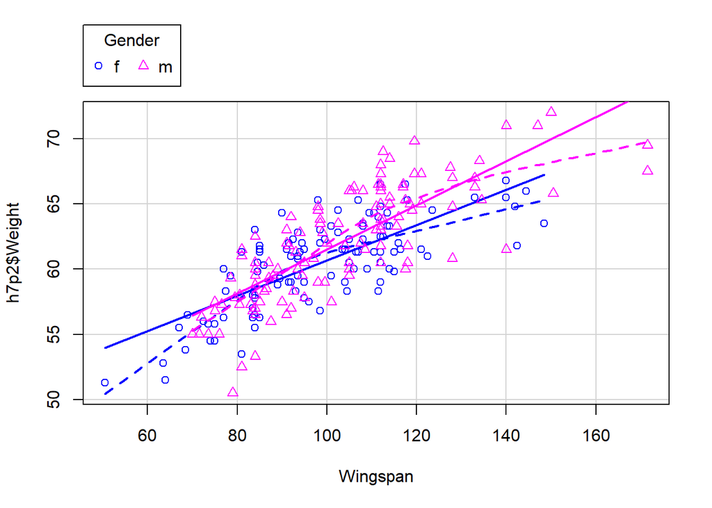

```r
scatterplot(h7p2$Weight~Wingspan|Gender)
```

```r
anova(aov(Wingspan~h7p2$Weight*Gender))
```

```
## Analysis of Variance Table
##
## Response: Wingspan
##                     Df Sum Sq Mean Sq  F value Pr(>F)
## h7p2$Weight          1  53555   53555 353.2040 <2e-16 ***
## Gender               1    129     129   0.8540 0.3564
## h7p2$Weight:Gender   1    181     181   1.1909 0.2763
## Residuals          233  35329     152
## ---
## Signif. codes:  0 '***' 0.001 '**' 0.01 '*' 0.05 '.' 0.1 ' ' 1
```

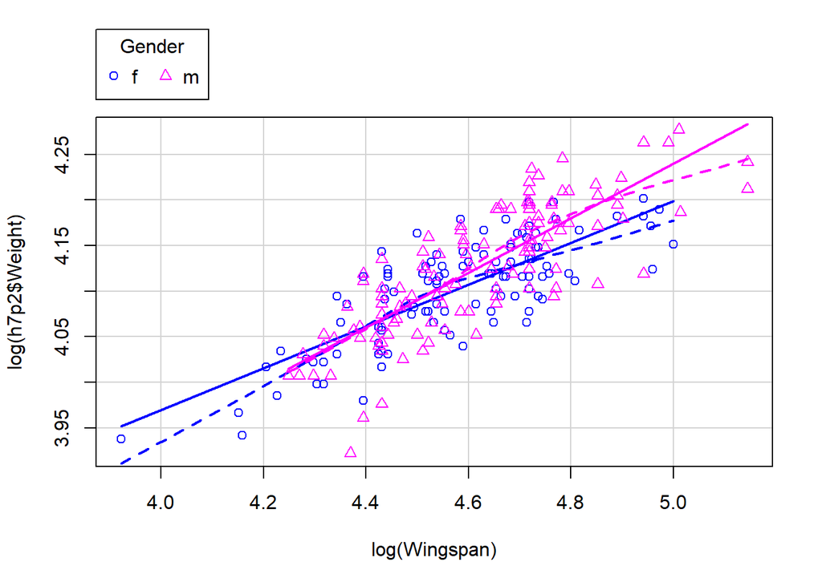

```r
scatterplot(log(h7p2$Weight)~log(Wingspan)|Gender)
```

```r
data2.aov <- aov(log10(h7p2$Weight)~log10(Wingspan)+Gender)
anova(data2.aov)
```

```
## Analysis of Variance Table
##
## Response: log10(h7p2$Weight)
##                  Df   Sum Sq  Mean Sq  F value  Pr(>F)
## log10(Wingspan)   1 0.117792 0.117792 411.1884 < 2e-16 ***
## Gender            1 0.001804 0.001804   6.2973 0.01277 *
## Residuals       234 0.067033 0.000286
## ---
## Signif. codes:  0 '***' 0.001 '**' 0.01 '*' 0.05 '.' 0.1 ' ' 1
```

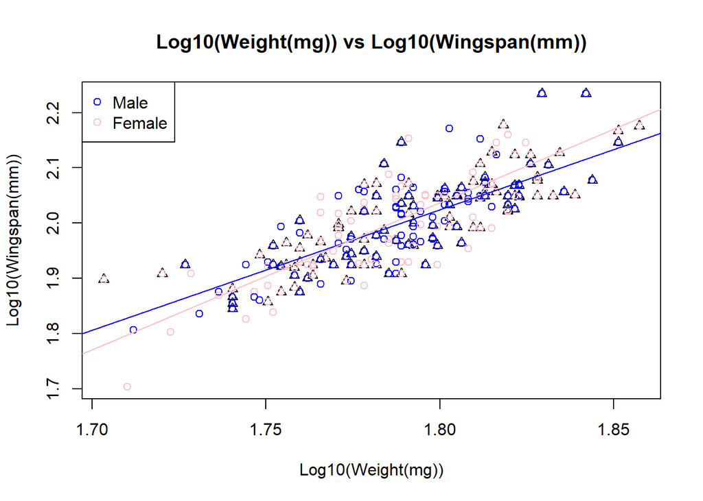

```r
plot(log10(h7p2$Weight), log10(Wingspan), pch=as.numeric(Gender), main = "Log10(Weight(mg)) vs Log10(Wingspan(mm))", xlab = "Log10(Weight(mg))", ylab = "Log10(Wingspan(mm))")
points(log10(h7p2$Weight), log10(Wingspan), col = c("Blue", "Pink"))
legend("topleft", legend = c("Male", "Female"), pch = as.numeric(Gender), col = c("Blue", "Pink"))

males <- h7p2[Gender=="m", ]
females <-h7p2[Gender=="f", ]

lm.males <- lm(log10(Wingspan)~log10(Weight), data=males)
lm.females <- lm(log10(Wingspan)~log10(Weight), data=females)

abline(lm.males, col = "Blue")
abline(lm.females, col = "Pink")
```

```r
summary(lm(log10(Wingspan)~log10(h7p2$Weight)+Gender))
```

```
##
## Call:
## lm(formula = log10(Wingspan) ~ log10(h7p2$Weight) + Gender)
##
## Residuals:
##       Min        1Q    Median        3Q       Max
## -0.116151 -0.036512 -0.004964  0.032940  0.146643
##
## Coefficients:
##                     Estimate Std. Error t value Pr(>|t|)
## (Intercept)        -2.215265   0.211943 -10.452   <2e-16 ***
## log10(h7p2$Weight)  2.359316   0.118954  19.834   <2e-16 ***
## Genderm            -0.005772   0.006690  -0.863    0.389
## ---
## Signif. codes:  0 '***' 0.001 '**' 0.01 '*' 0.05 '.' 0.1 ' ' 1
##
## Residual standard error: 0.05043 on 234 degrees of freedom
## Multiple R-squared:  0.6323, Adjusted R-squared:  0.6292
## F-statistic: 201.2 on 2 and 234 DF,  p-value: < 2.2e-16
```

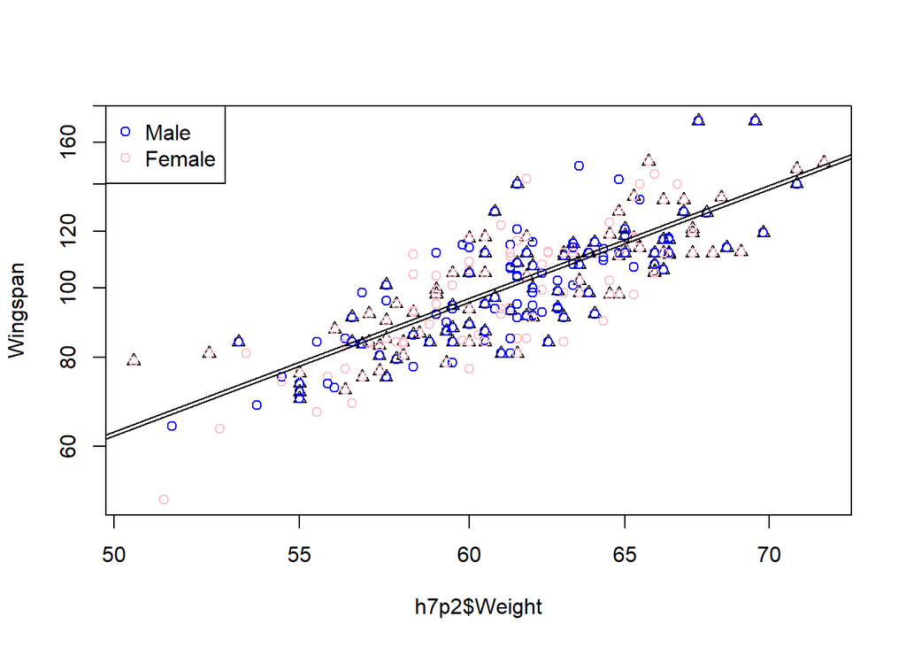

```r
plot(h7p2$Weight, Wingspan, pch=as.numeric(Gender), log="xy")
points(h7p2$Weight,Wingspan, col = c("Blue", "Pink"))
legend("topleft", legend = c("Male", "Female"), pch = as.numeric(Gender), col = c("Blue", "Pink"))

abline(a=-2.215265, b=2.359316)
abline(a=-2.215265+0.005772, b=2.359316)
```

### CONCLUSION

There is a significant effect of Weight on Wingspan after controlling for gender (F(2,234) = 201.2, p <<< 0.05).